# Part II - (Explanatory Visualization)

## by (Joshua Regan Lenge)

### Udacity Data Visualization Project.

## Investigation Overview

The aim of these visualizations is to summarize the insights from our `exploratory visuals`.

## Dataset Overview

- The dataset `Prosper_clean.csv` is has been wrangled in the previous section `part I - (Exploratory Visualization)`. Although not all variables were explored, the dataset contains only variables of interest to our analysis.

### Summary of Key insghts

#### From our exploratory visualization, we observed that

1. `LoanStatus` is majorly affected by;
   - `IncomeRange`
   - `EmploymentStatus`
   - `CreditGrade`
2. `BorrowerAPR` is majorly inlfuenced by;
   - `LoanOriginalAmount`
   - Home ownership `IsBorrowerHomeowner`
3. As observed, home owners have significantly lower `BorrowerAPR`, and high `LoanOriginalAmount` is associated with lower `BorrowerAPR`, this implies that Home owners take significantly higher loans and have a higher purchasing power. This shows that a sense of security plays of spending power.
4. Categorical variables are largely classifcations based on client psychology, the data suggests that less than `50%` of clients are satisfied with the organisations loans conditions/ structure, this is not to imply poor customer service or the neglect of customer feedback, but could be a result of other factors outside the scope of the variables provided by this data. Thus more categorical variables would help understand client better.

**However, this is a business and should be treated as such.**

## Visualization 1

## (Visualization 1)

- With the exception of `Current` loans, all other `Loan Status` are dominated by those who do not own homes, this as we would see in the next visuals is largely because Home owners can afford to take more loans, while those who do not own homes have to worry (possibly) about rent, and other financial commitments.

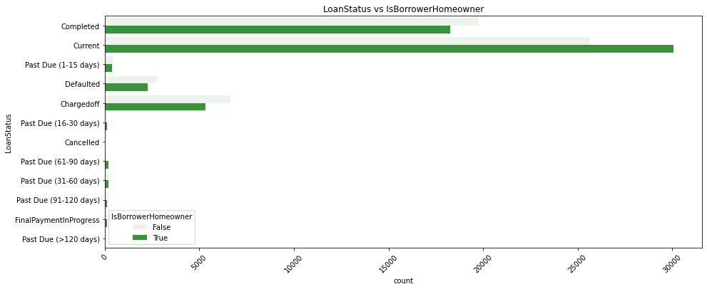

## (Visuaization 2)

- Here, we see an interesting relationship between `Homeownership`, `Loan original amount` and `Borrower Apr`.
- Home owners have significantly lower `Borrower APR` attatched to their loans while those who do not own homes have higher `Borrower APR`.
- Also, those who own homes take on larger loan amounts than those who do not own any homes, This could be because those who own homes have less to worry about rent and can channel those funds to more productive ventures on which the loans taken complement profitability.

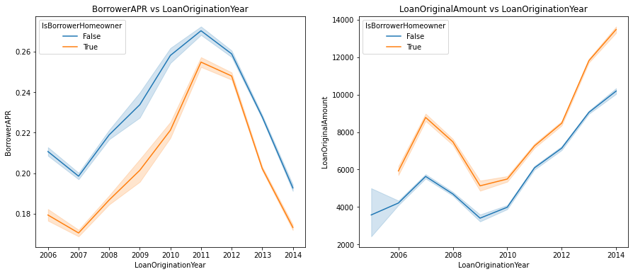

## (Visualization 3)

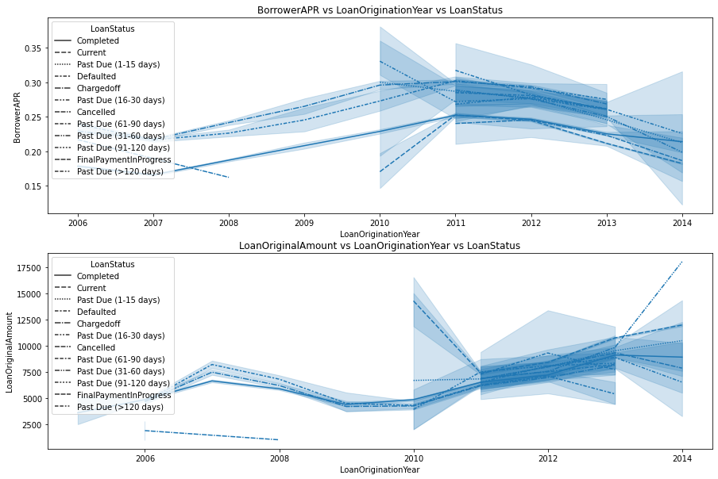

[output not shown]